# Loss Functions and Scoring Rules

Lecture 16

March 2, 2026

# Last Classes

## Modeling Extremes

**Values with a very low probability of occurring**, not necessarily high-impact events (which don’t have to be rare!).

1. “Block” extremes, *e.g.* annual maxima (**block maxima**): Generalized Extreme Value distributions
2. Values which exceed a certain threshold (**peaks over threshold**): Poisson-Generalized Pareto processes

## Return Levels and Periods

The **$T$-year return level** is the value expected to be observed **on average** once every $T$ years.

The **return period** of an extreme value is the inverse of the exceedance probability.

**Example**: The 100-year return period has an exceedance probability of 1%, *e.g.* the 0.99 quantile.

Return levels are associated with the analogous return period.

## Nonstationary Models

- Generalized linear models for extreme values; e.g.
  $$y_i \sim \text{GEV}(\mu_0 + \mu_1 x_i, \sigma, \xi)$$
- Return periods are now dependent on covariate value $x_i$
- Usually good practice to not make $\xi$ nonconstant.

# How Can Modeling Go Wrong?

## What Are Models For?

- Data summaries/compression;
- Inference about parameters/processes;
- Predictors of other/new data;
- Simulators of counterfactuals (causal analysis).

## Why Predictive Skill?

- In general, we use predictive skill to evaluate models because it gives us a principled approach and a model that is better ought to predict better.
- Examining predictions is usually the best way to evaluate a statistical model.
- However, models that are “right” may do less well at prediction than models that are “wrong” due to noise or confounding factors.

[figure not shown]

Causality Correlation Metric

Source: Richard McElreath

# Measuring Model Skill

## $R^2$ for Point Predictions

$$R^2 = (\sigma^2_\text{model}/\sigma^2_\text{data})$$

- Probably most common, also only meaningful for linear Gaussian models $y \sim N(\beta_0 + \beta_1 x, \sigma^2)$.
- Increasing predictors **always** increases $R^2$, making it useless for model selection.
- Can adjust for increasing complexity, substitute
  $$R^2_\text{adj} = 1 - ((n / (n-2)) \sigma^2_\text{residuals} / \sigma^2_\text{data})$$
- **Does not do what people think it does except in very limited cases**.

## Gaming Statistics with Outliers

[figure not shown]

SMBC: Take It Off

Source: [Saturday Morning Breakfast Cereal](https://www.smbc-comics.com/comic/take-it-off)

## Anscombe’s Quartet Illustrates Problems With $R^2$

Anscombe’s Quartet (Anscombe, 1973) consists of datasets which have the same summary statistics (including $R^2$) but very different graphs.

[figure not shown]

Anscombe’s Quartet

Source: [Wikipedia](https://en.wikipedia.org/wiki/Anscombe%27s_quartet)

## Alternatives to $R^2$

In pretty much every case where $R^2$ *might* be useful, **(root) mean squared error ((R)MSE)** is better:

More generally, we want to think about measures which capture the skill of a **probabilistic prediction**.

These are commonly called **scoring rules** (Gneiting & Katzfuss, 2014) (more on this next class).

## Measuring Errors

Suppose we have a dataset $\mathbf{z}_n = \{z_1, z_2, \ldots, z_n\}$ and various models $\mathcal{M} = \{M_1, M_2, \ldots, M_k\}$ parameterized by $\theta_i, \ldots, \theta_k$.

Then the prediction our model makes at a new predictor $\mathbf{x}$ is $M_i(\mathbf{x}; \theta_i)$.

Finally, we have a **loss function** $L$ which tells us how to penalize errors, *e.g.* for MSE use the **quadratic loss**
$$L(z, M, \theta) = \left(y - M(\mathbf{x}; \theta)\right)^2.$$

## Other Examples of Loss Functions

- Mean Absolute Error:
  $$L(z, M, \theta) = \left|y - M(\mathbf{x}; \theta)\right|.$$
- 0-1 Loss:
  $$L(z, M, \theta) = \begin{cases}1 & \text{if}\ y = M(\mathbf{x}, \theta) \\ 0 & \text{if}\ y \neq M(\mathbf{x}, \theta).\end{cases}$$

## Other Examples of Loss Functions

- Log Loss:
  $$L(z, M, \theta) = -\log(p(y; M(\mathbf{x}; \theta))).$$

## Loss and Learning Theory

- We would like to have zero errors if possible; this is impossible.
- Ideally, we would calculate the **expected error** or **risk**:
  $$\mathbb{E}[L(Z, M, \theta) = \int_Z L(z, M, \theta) p(z)\,dz.$$
  But this would require us to know the full distribution of $Z = (X, Y)$.

## Loss and Learning Theory

- Instead, try to find the parameters/models which **minimize the in-sample loss**:

$$\hat{\theta_n} = \text{argmin}_{\theta \in \Theta} \bar{L}(\mathbf{y}_n, M, \theta).$$

This means minimizing MSE/SSE or maximizing likelihood for the quadratic or log losses.

# Probabilistic Prediction Skill

## What Makes A Good Prediction?

What do we want to see in a probabilistic projection $F$?

- **Calibration**: Does the predicted CDF $F(y)$ align with the “true” distribution of observations $y$?
  $$\mathbb{P}(y \leq F^{-1}(\tau)) = \tau \qquad \forall \tau \in [0, 1]$$
- **Dispersion**: Is the concentration (variance) of $F$ aligned with the concentration of observations?
- **Sharpness**: How concentrated are the forecasts $F$?

## Probability Integral Transform (PIT)

Common to use the PIT to make these more concrete: $Z_F = F(y)$.

The forecast is **probabilistically calibrated** if $Z_F \sim Uniform(0, 1)$.

The forecast is **properly dispersed** if $\text{Var}(Z_F) = 1/12$.

**Sharpness** can be measured by the width of a particular prediction interval. **A good forecast is a sharp as possible subject to calibration** (Gneiting et al., 2007).

## PIT Example: Well-Calibrated

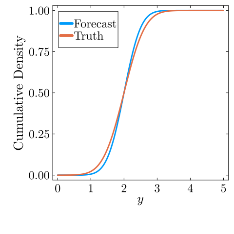

(a) Comparison of “proper” and overdispersed PIT.

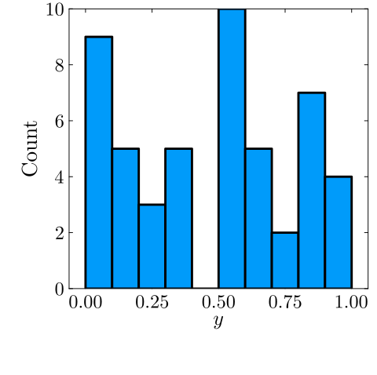

(b)

Figure 1

```julia
# "true" observation distribution is N(2, 0.5)
obs = rand(Normal(2, 0.5), 50)
# forecast according to the "correct" distribution and obtain PIT
pit_corr = cdf(Normal(2, 0.45), obs)
p_corr = histogram(pit_corr, bins=10, label=false, xlabel=L"$y$", ylabel="Count", size=(500, 500))

xrange = 0:0.01:5
p_cdf1 = plot(xrange, cdf.(Normal(2, 0.4), xrange), xlabel=L"$y$", ylabel="Cumulative Density", label="Forecast", size=(500, 500))
plot!(p_cdf1, xrange, cdf.(Normal(2, 0.5), xrange), label="Truth")

display(p_cdf1)
display(p_corr)
```

## PIT Example: Underdispersed

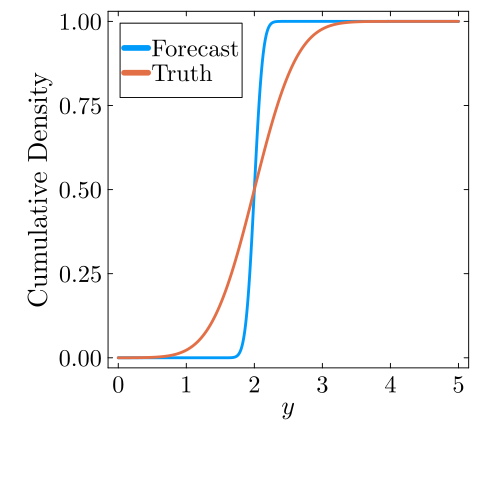

(a) Comparison of “proper” and overdispersed PIT.

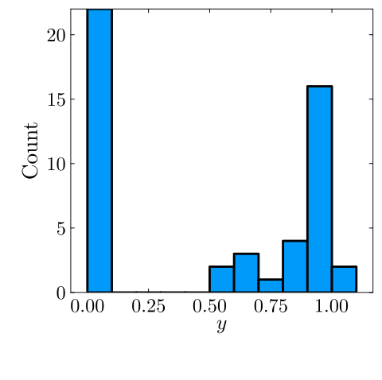

(b)

Figure 2

```julia
# forecast according to an underdispersed distribution and obtain PIT
pit_under = cdf(Normal(2, 0.1), obs)
p_under = histogram(pit_under, bins=10, label=false, xlabel=L"$y$", ylabel="Count", size=(500, 500))

xrange = 0:0.01:5
p_cdf2 = plot(xrange, cdf.(Normal(2, 0.1), xrange), xlabel=L"$y$", ylabel="Cumulative Density", label="Forecast", size=(500, 500))
plot!(p_cdf2, xrange, cdf.(Normal(2, 0.5), xrange), label="Truth")

display(p_cdf2)
display(p_under)
```

## PIT Example: Overdispersed

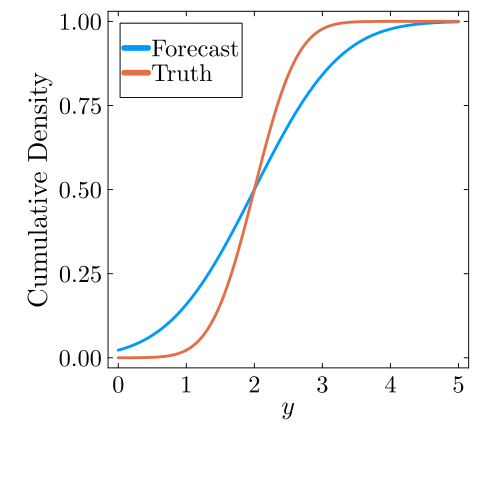

(a) Comparison of “proper” and overdispersed PIT.

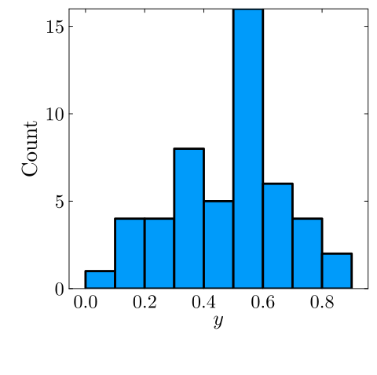

(b)

Figure 3

```julia
# forecast according to an overdispersed distribution and obtain PIT
pit_over = cdf(Normal(2, 1), obs)
p_over = histogram(pit_over, bins=10, label=false, xlabel=L"$y$", ylabel="Count", size=(500, 500))

xrange = 0:0.01:5
p_cdf3 = plot(xrange, cdf.(Normal(2, 1), xrange), xlabel=L"$y$", ylabel="Cumulative Density", label="Forecast", size=(500, 500))
plot!(p_cdf3, xrange, cdf.(Normal(2, 0.5), xrange), label="Truth")

display(p_cdf3)
display(p_over)
```

## Scoring Rules

**Scoring rules** compare observations against an entire probabilistic forecast.

A scoring rule $S(F, y)$ measures the “loss” of a predicted probability distribution $F$ once an observation $y$ is obtained.

Typically oriented so smaller = better.

## Scoring Rule Examples

1. Logarithmic: $S(F, y) = -\log F(y)$
2. Quadratic (Brier): $S(F, y) = -2F(y) - \int_{-\infty}^\infty F^2(z) dz$ / $B(F, y) = \sum_i (y_i - F(y_i))^2$
3. Continous Ranked Probability Score (CRPS):
   $$\begin{align*}
   S(F, y) &= -\int (F(z) - \mathbb{I}(y \leq z))^2 dz \\
   &= \mathbb{E}_F |Y -y| - \frac{1}{2} E_F | Y - Y'|
   \end{align*}$$

## Proper Scoring Rules

**Proper** scoring rules are intended to encourage forecasters to provide their full (and honest) forecasts.

Minimized when the forecasted distribution matches the observed distribution:

$$\mathbb{E}_Y(S(G, G)) \leq \mathbb{E}_Y(S(F, G)) \qquad \forall F.$$

It is **strictly proper** if equality holds only if $F = G$.

## Sidenote: Why Not Use Classification Accuracy?

Most classification algorithms produce a probability (*e.g.* logistic regression) of different outcomes.

A common skill metric for classification models is **accuracy** (sensitivity/specificity): given these probabilities and some threshold to translate them into categorical prediction.

## The Problem With Classification Accuracy

**The problem**: This translation is a *decision* problem, not a *statistical problem*. A probabilistic scoring rule over the predicted probabilities more accurately reflects the skill of the statistical model.

## Logarithmic Score As Scoring Rule

The **logarithmic score** $S(F, y) = -\log F(y)$ is (up to equivalence) the only **local** strictly proper scoring rule (locality ⇒ score depends only on the observation).

This is the negative log-probability: straightforward to use for the likelihood (frequentist forecasts) or posterior (Bayesian forecasts) and generalizes MSE.

### Key Points and Upcoming Schedule

## Upcoming Schedule

**Wednesday**: Bias and Variance and Tradeoffs

**Friday**: Cross-Validation

## Assessments

**HW3**: Due Friday

**Quiz 2**: **Next** Friday, 3/13

# References

## Refernences (Scroll for Full List)

Anscombe, F. J. (1973). Graphs in Statistical Analysis. *Am. Stat.*, *27*, 17. https://doi.org/10.2307/2682899

Gneiting, T., & Katzfuss, M. (2014). Probabilistic Forecasting. *Annual Review of Statistics and Its Application*, *1*, 125–151. https://doi.org/10.1146/annurev-statistics-062713-085831

Gneiting, T., Fadoua Balabdaoui, & Raftery, A. E. (2007). Probabilistic Forecasts, Calibration and Sharpness. *J. R. Stat. Soc. Series B Stat. Methodol.*, *69*, 243–268. Retrieved from http://www.jstor.org/stable/4623266